# Homework 2

STAT 430, Spring 2017

Due: Friday, February 10 by 11:59 PM

# Exercise 1

**[14 points]** In this exercise, you will investigate the bias-variance tradeoff when estimating the function $f$ defined below.

```r
f = function(x1, x2) {
  x1 ^ 3 + x2 ^ 3
}
```

The following code defines the data generating process and should we used to simulate data.

```r
get_sim_data = function(f, sample_size = 100) {
  x1 = runif(n = sample_size, min = -1, max = 1)
  x2 = runif(n = sample_size, min = -1, max = 1)
  y = f(x1, x2) + rnorm(n = sample_size, mean = 0, sd = 0.5)
  data.frame(x1, x2, y)
}
```

Use simulation to investigate the bias and variance of *five* models at the point ${\bf x} = (x_1, x_2) = (0.75, 0.95)$. The five models are of the form

- `y ~ poly(x1, degree = k) + poly(x2, degree = k)`

for $k = 1, 2, 3, 4, 5$. Use 500 simulated samples each of size 200. Before performing the simulations, you should set a seed equal to your UIN. For example,

```r
uin = 123456789
set.seed(uin)
```

**Summarize your results as a *single* plot** which compares both **squared bias** and **variance** of the estimates to the **degree** of the polynomials used. That is, the x-axis should be **degree** and you should have a line for both **squared bias** and **variance**. Comment on the plot. Are the results what you expected? Explain. (A few points may not strictly follow the general pattern as a result of the randomness of the simulation.)

**Solution:**

```r
n_sims = 500
n_models = 5
x0 = data.frame(x1 = 0.75, x2 = 0.95)
predictions = matrix(0, nrow = n_sims, ncol = n_models)

for (i in 1:n_sims) {

  sim_data = get_sim_data(f, sample_size = 200)

  fit_1 = lm(y ~ poly(x1, 1) + poly(x2, 1), data = sim_data)
  fit_2 = lm(y ~ poly(x1, 2) + poly(x2, 2), data = sim_data)
  fit_3 = lm(y ~ poly(x1, 3) + poly(x2, 3), data = sim_data)
  fit_4 = lm(y ~ poly(x1, 4) + poly(x2, 4), data = sim_data)
  fit_5 = lm(y ~ poly(x1, 5) + poly(x2, 5), data = sim_data)

  predictions[i, ] <- c(
    predict(fit_1, newdata = x0),
    predict(fit_2, newdata = x0),
    predict(fit_3, newdata = x0),
    predict(fit_4, newdata = x0),
    predict(fit_5, newdata = x0)
  )
}
```

```r
eps = rnorm(n = n_sims, mean = 0, sd = 0.5)
y0 = f(x1 = 0.75, x2 = 0.95) + eps
```

```r
get_bias = function(estimate, truth) {
  mean(estimate) - truth
}

get_mse = function(estimate, truth) {
  mean((estimate - truth) ^ 2)
}
```

```r
bias = apply(predictions, 2, get_bias, f(x1 = 0.75, x2 = 0.95))
variance = apply(predictions, 2, var)
mse = apply(predictions, 2, get_mse, y0)
```

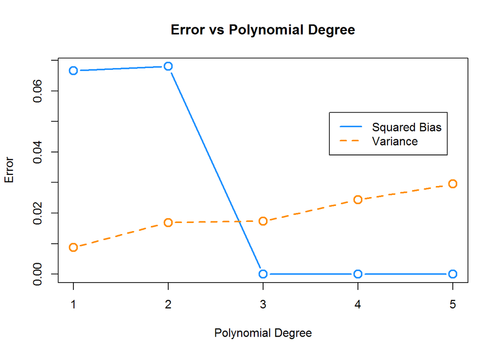

```r
plot(bias ^ 2, type = "b", col = "dodgerblue", cex = 1.5, lwd = 2,
     xlab = "Polynomial Degree", ylab = "Error",
     main = "Error vs Polynomial Degree")
lines(variance, type = "b", col = "darkorange", cex = 1.5, lwd = 2, lty = 2)
legend(x = 3.7, y = 0.053,
       c("Squared Bias", "Variance"),
       col = c("dodgerblue", "darkorange", "green", "orange", "black"),
       lty = c(1, 2), lwd = 2)
```

Here we mostly see the expected pattern. Squared bias (blue) generally decreases as the model complexity (polynomial degree) increases. On the other hand, variance (orange) increases as model complexity increases.

# Exercise 2

**[8 points]** For this exercise use the data found in `hw02-train.csv` and `hw02-test.csv` which contain train and test data respectively.

```r
library(tibble)
library(readr)

g = function(x1, x2, x3, x4) {
  3 + 0.5 * x1 * x2 + x3 + 0.2 * x4 ^ 3
}

make_hw02_data = function(n_obs = 1000) {

  x1 = runif(n = n_obs, min = 0, max = 3)
  x2 = rbinom(n = n_obs, size = 1, p = 0.5)
  x3 = runif(n = n_obs, min = 0, max = 1)
  x4 = rnorm(n = n_obs, mean = 0, sd = 2)

  eps = rnorm(n = n_obs, mean = 0 , sd = 1)

  y = g(x1, x2, x3, x4) + eps

  tibble(y, x1, x2, x3, x4)

}

set.seed(42)
hw02_train = make_hw02_data()
hw02_test  = make_hw02_data()
write_csv(hw02_train, "hw02-train.csv")
write_csv(hw02_test, "hw02-test.csv")
```

Find a model by fitting to the training data which achieves:

- Train RMSE less than 1.08
- Test RMSE less than 1.01

Report the model you found (you may use `R` formula notation), as well as the two metrics.

**Solution:**

We first read in the data, and write some helper function.

```r
hw02_train = read_csv("hw02-train.csv")
hw02_test = read_csv("hw02-test.csv")
```

```r
rmse = function(actual, predicted) {
  sqrt(mean((actual - predicted) ^ 2))
}

get_rmse = function(model, data, response) {
  rmse(actual = data[, response],
       predicted = predict(model, data))
}
```

By plotting the data, we immediately get a sense of a good model, in particular, one which contains a polynomial term of degree 3 for `x4`.

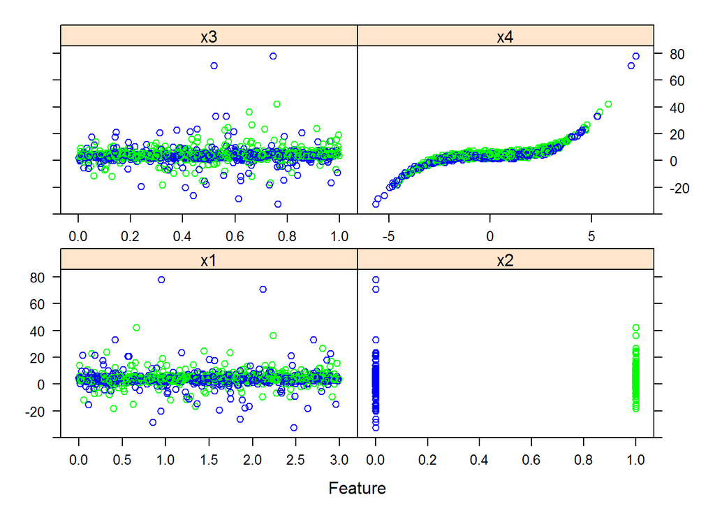

```r
library(caret)
featurePlot(x = hw02_train[, c("x1", "x2", "x3", "x4")],
            y = hw02_train$y,
            col = ifelse(hw02_train$x2, "Green", "Blue"))
```

Here we report the best model. (See the data generation above.) Mostly models using all predictors and a polynomial term of degree 3 for `x4` should work well.

```r
fit = lm(y ~ x1 * x2 + x3 + poly(x4, degree = 3), data = hw02_train)
c(get_rmse(model = fit, data = hw02_train, response = "y"),
  get_rmse(model = fit, data = hw02_test, response = "y"))
```

```
## [1] 1.029970 0.979488
```

| Model | Train RMSE | Test RMSE |
| --- | --- | --- |
| `y ~ x1 * x2 + x3 + poly(x4, degree = 3)` | 1.0299703 | 0.979488 |

# Exercise 3

**[8 points]** For this exercise use the data found in `auto-train.csv` and `auto-test.csv` which contain train and test data respectively. `auto.csv` is provided but not used. It is a modification of the `Auto` data from the `ISLR` package. For information on the original data:

```r
library(ISLR)
#?Auto
```

Use the training data to train a classifier for `mpg` which achieves:

- Train Accuracy greater than 0.89
- Test Accuracy greater than 0.89

Report these metrics, as well as the confusion matrix, sensitivity, and specificity for the test data.

**Solution:**

```r
auto_train = read_csv("auto-train.csv")
auto_test = read_csv("auto-test.csv")
```

By plotting the data, we “train” a classifier by noticing a reasonable split around a displacement of 185.

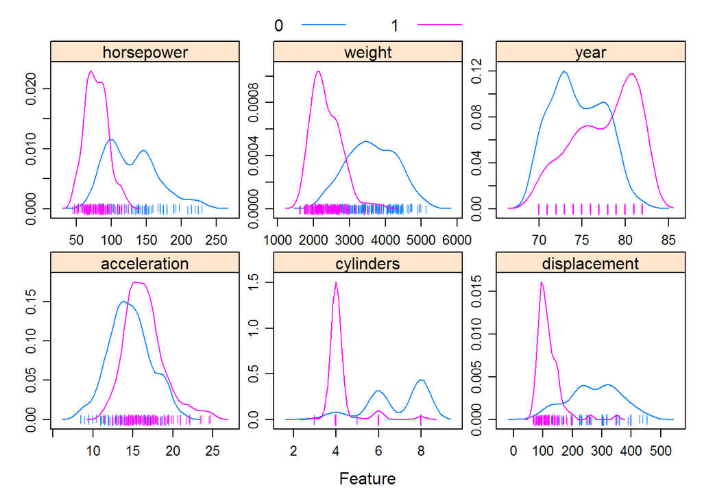

```r
featurePlot(x = auto_train[, 2:7],
            y = as.factor(auto_train$mpg),
            plot = "density",
            scales = list(x = list(relation="free"),
                          y = list(relation="free")),
            adjust = 1,
            pch = "|",
            layout = c(3, 2),
            auto.key = list(columns = 2))
```

We write a simple `R` function to perform this classification.

```r
simple_class = function(x, cutoff, above = 1, below = 0) {
  ifelse(x > cutoff, above, below)
}
```

We then obtain predictions for both the train and test data, which we then place into crosstables with their true values.

```r
train_pred = simple_class(auto_train$displacement,
                          cutoff = 185, above = 0, below = 1)
test_pred  = simple_class(auto_test$displacement,
                          cutoff = 185, above = 0, below = 1)
```

```r
train_tab = table(predicted = train_pred, actual = auto_train$mpg)
test_tab = table(predicted = test_pred, actual = auto_test$mpg)
```

**Train Accuracy:**

```r
confusionMatrix(train_tab)$overall["Accuracy"]
```

```
## Accuracy
##      0.9
```

**Test Confusion:**

```r
confusionMatrix(test_tab)$table
```

```
##          actual
## predicted  0  1
##         0 42  0
##         1  8 42
```

**Test Metrics:**

```r
c(confusionMatrix(test_tab)$overall["Accuracy"],
  confusionMatrix(test_tab)$byClass["Sensitivity"],
  confusionMatrix(test_tab)$byClass["Specificity"])
```

```
##    Accuracy Sensitivity Specificity
##   0.9130435   0.8400000   1.0000000
```